# Fighting for growth: labour scarcity and technological progress during the British Industrial Revolution *American Economic Review* 2026 (forthcoming), March 6 → June 5 drafts

Hans-Joachim Voth, Bruno Caprettini, and Alex Trew (author order randomised per AEA guidelines)

Author

伊藤成朗

Published

September 02, 2026, 11:09 +0900

# Outline

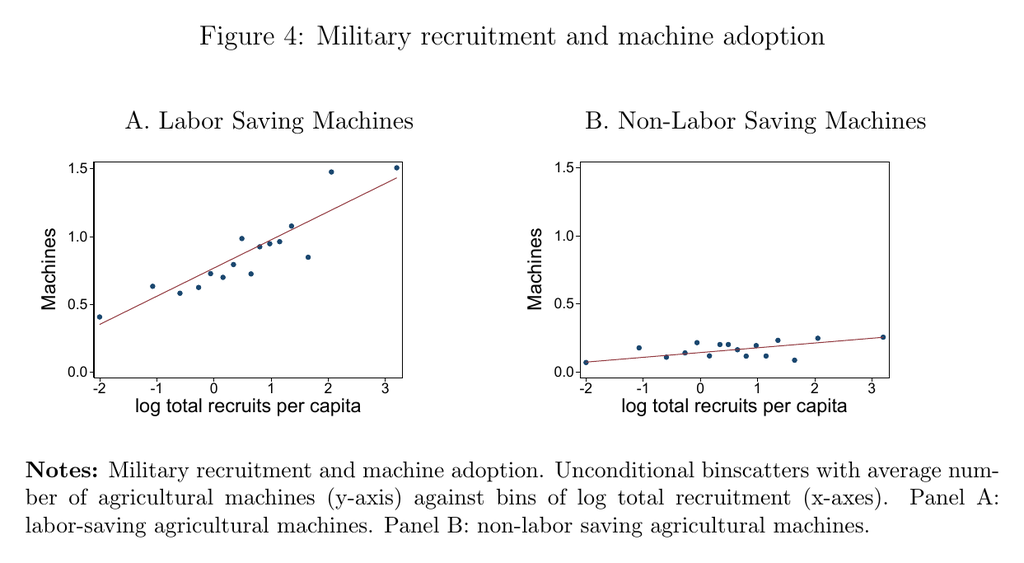

Fig 4: OLS binscatters

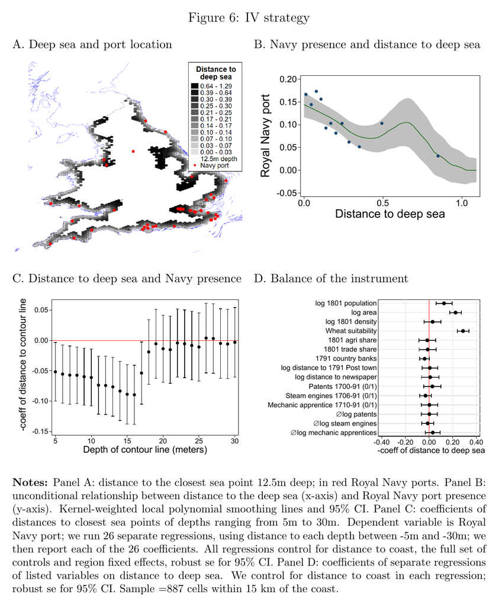

Fig 6: distance to deep sea

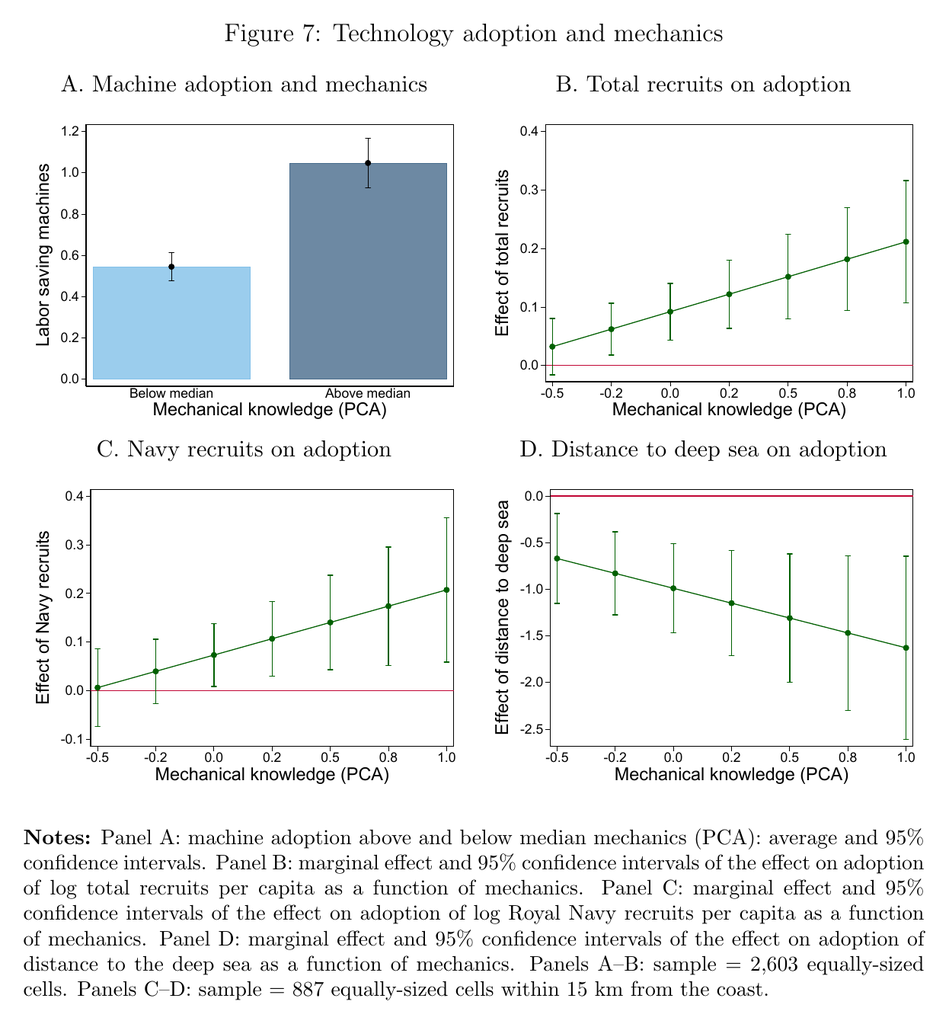

Fig 7: skills × scarcity synergy

Napoleonic-war military recruitment ⇒ local labour scarcity ⇒ adoption of **labour-saving** machinery in industrialising England.

1. Recruitment shock (1793–1815)
   - >10% of the male population under arms; army + navy ≃ 350K at peak
   - Navy grew 16K (1792) → ≃150K (1812)
2. Labour scarcity
   - Skewed sex ratios (“missing men”)↑ where recruitment was heavy
   - Wages↑ (winter +103%, summer +104%, 1790–1811)
3. Technology adoption
   - Labour-saving machines (threshers etc.)↑
   - Non-labour-saving machines: no effect←
4. Identification
   - Navy recruitment instrumented by distance to deep, navigable sea (12.5 m contour)
   - Coastal sample only, controlling for distance to coast
5. Synergy
   - Where mechanical skills↑ (apprentices, patents), the scarcity effect on adoption↑
   - Unifies Allen (labour costs) and Mokyr (human capital)
6. Long run
   - Machines stayed after 1820; RASE machine productivity↑ where wartime adoption↑
   - Structural change out of agriculture↑

# Motivation

Two rival explanations of the British Industrial Revolution:

1. Allen (2009): “invented in Britain … because that was where it paid to invent it”
   - High wages + cheap energy ⇒ directed technical change (Hicks 1932; Habakkuk 1962; Acemoglu 2007)
2. Mokyr (2009): human capital / Enlightenment culture
   - Abundance of “savants and mechanics”; industrialisation began where skilled craftsmen were (Kelly et al. 2022), not where wages were high

Identification challenge

- Need cross-sectional variation in labour scarcity that is **exogenous**, not just local economic conditions
- Skill-availability and technology-adoption data have hitherto been unavailable
- Open question (Crafts 2011): did labour shortages facilitate the transition to self-sustaining growth?

This paper: a unified view assigning a role to **both** labour scarcity and human capital, using four newly-collected datasets.

# Existing literature

The paper sits at the intersection of two strands: **directed technical change** (DTC) and the **origins of the British Industrial Revolution**.

**Directed technical change — theory**

Labour scarcity raises the payoff to labour-saving invention (Hicks 1932; Habakkuk 1962; Acemoglu 2002, 2003, 2007).

Hicks, John R. 1932. *The Theory of Wages*. London: Macmillan.

Habakkuk, H. J. 1962. *American and British Technology in the Nineteenth Century: The Search for Labour-Saving Inventions*. Cambridge: Cambridge University Press.

Acemoglu, Daron. 2002. “Directed Technical Change.” *The Review of Economic Studies* 69 (4): 781–809. https://doi.org/10.1111/1467-937X.00226.

———. 2003. “Labor- and Capital-Augmenting Technical Change.” *Journal of the European Economic Association* 1 (1): 1–37. https://doi.org/10.1162/154247603322256756.

———. 2007. “Equilibrium Bias of Technology.” *Econometrica* 75 (5): 1371–1409. https://doi.org/10.1111/j.1468-0262.2007.00797.x.

- Key refinement: only *strongly* labour-saving technologies benefit from scarcity — factor bias matters.

**Directed technical change — empirical (scarcity → innovation)**

Exogenous factor-supply shocks redirect invention toward the scarce factor.

- Hanlon (2015): the US Civil War cotton-supply shock pushed UK textile inventors toward machines for non-US cotton yarns.
- Andersson, Karadja, and Prawitz (2022) and San (2023): mass emigration and the end of the Bracero programme each raised labour-saving innovation.

Hanlon, W. Walker. 2015. “Necessity Is the Mother of Invention: Input Supplies and Directed Technical Change.” *Econometrica* 83 (1): 67–100. https://doi.org/10.3982/ECTA10811.

Andersson, David, Mounir Karadja, and Erik Prawitz. 2022. “Mass Migration and Technological Change.” *Journal of the European Economic Association* 20 (5): 1859–96. https://doi.org/10.1093/jeea/jvac017.

San, Shmuel. 2023. “Labor Supply and Directed Technical Change: Evidence from the Termination of the Bracero Program in 1964.” *American Economic Journal: Applied Economics* 15 (1): 136–63. https://doi.org/10.1257/app.20200664.

**Wages → technology adoption / automation**

Higher relative labour cost accelerates adoption and automation.

- Lewis (2011) (US manufacturing), Acemoglu and Restrepo (2020) (robots across US cities and industries), Acemoglu and Finkelstein (2008, US health).
- Contrary/ambiguous: Franck (2022, 19C France); Dower and Markevich (2018) — Russian WWI mobilisation cut cultivation rather than mechanising.
- Capital–labour substitution via higher wages: Hornbeck and Naidu (2014), Clemens et al. (2018), Abramitzky et al. (2022) — but new capital need not embody new technology, so weaker DTC evidence.

Lewis, Ethan. 2011. “Immigration, Skill Mix, and Capital-Skill Complementarity.” *The Quarterly Journal of Economics* 126 (2): 1029–69. https://doi.org/10.1093/qje/qjr011.

———. 2020. “Robots and Jobs: Evidence from US Labor Markets.” *Journal of Political Economy* 128 (6): 2188–2244. https://doi.org/10.1086/705716.

Hornbeck, Richard, and Suresh Naidu. 2014. “When the Levee Breaks: Black Migration and Economic Development in the American South.” *American Economic Review* 104 (3): 963–90. https://doi.org/10.1257/aer.104.3.963.

**Origins of the British Industrial Revolution**

Competing accounts of “what made Britain special”.

- Institutions (North and Weingast 1989), colonies (Inikori 2002), culture (McCloskey 2010), natural resources (Wrigley 2010), chance (Crafts 1985), reconstructed national accounts (Broadberry et al. 2015).
- High-wage economy (Allen 2009): dear labour + cheap energy made labour-saving invention pay.
- Human capital / skilled mechanics (Mokyr 2009; Kelly, Mokyr, and Ó Gráda 2023): abundant trained mechanics enabled a stream of micro-inventions.

Crafts, N. F. R. 1985. *British Economic Growth During the Industrial Revolution*. Oxford: Oxford University Press.

Broadberry, Stephen, Bruce M. S. Campbell, Alexander Klein, Mark Overton, and Bas van Leeuwen. 2015. *British Economic Growth, 1270–1870*. Cambridge: Cambridge University Press.

Allen, Robert C. 2009. *The British Industrial Revolution in Global Perspective*. Cambridge: Cambridge University Press.

Mokyr, Joel. 2009. *The Enlightened Economy: The Economic History of Britain, 1700–1850*. New Haven, CT: Yale University Press.

**Scope note — these two are not the only accounts, but the paper is *not* omitting the rest**

Allen vs Mokyr are two of many “why Britain” theses (institutions, coal/geography, trade/colonies, demography).

- The design uses **within-England** spatial variation ⇒ *national* rivals (1688 institutions, empire, culture, national coal endowment) are differenced out
- *Local* versions are controlled: coal deposits (Fernihough–O’Rourke, Table A.10), enclosure (A.34), finance/steam/patents (matching covariates)
- It tests a *mechanism* (scarcity → mechanisation, 1790–1820), not the *origin* of the IR — so the grand rivals are scope conditions, not competitors here

**Empirical tests of the grand hypotheses (data / identification / estimator / result)**

How the rival theses have themselves been tested.

- **Kelly, Mokyr, and Ó Gráda (2023)** (JPE) — *rejects Allen’s high-wage premise*
  - Data: 41 English counties, 1760s–1830s (textile growth, initial wages, mechanical skills, literacy, banks, coal)
  - Identification / estimator: cross-county **semiparametric spatial regression** (spatial smooth), descriptive (N = 41)
  - Result: industry rose in *low-wage, high-mechanical-skill* counties; low wages in the 1760s alone explain **~70%** of textile-employment variation; literacy/banks/coal add little (they flag 1790s mechanical skill as possibly endogenous)
- **Squicciarini and Voigtländer (2015)** (QJE) — *supports Mokyr (upper-tail)*
  - Data: French cities; Encyclopédie subscriber density (upper-tail proxy) vs literacy (average HC)
  - Identification / estimator: **OLS** (cross-section + panel) + placebo/timing (matters only *after* 1750) + controls + patent/firm mechanism — **no IV** (confirmed at source)
  - Result: upper-tail knowledge ⇒ faster growth; literacy doesn’t
- **Dittmar (2011)** (QJE) — *causal information-technology effect*
  - Data: European cities 1500–1600; presses set up in the 1400s
  - Identification / estimator: **IV = distance from Mainz** ⇒ 2SLS; placebo distances (Venice/Amsterdam/London/Wittenberg) insignificant
  - Result: print-adopting cities grew **~60% faster** 1500–1600
- *External validity*: all three are place/period-specific historical cross-sections — suggestive, not a general law
- *Source-verification*: all three read at source (local PDFs, stored in `paper_digest.sqlite`) — KMOG uses semiparametric spatial regressions (not plain OLS); S–V uses **no IV**; Dittmar’s distance-from-Mainz IV confirmed

Kelly, Morgan, Joel Mokyr, and Cormac Ó Gráda. 2023. “The Mechanics of the Industrial Revolution.” *Journal of Political Economy* 131 (1): 59–94. https://doi.org/10.1086/720890.

Squicciarini, Mara P., and Nico Voigtländer. 2015. “Human Capital and Industrialization: Evidence from the Age of Enlightenment.” *The Quarterly Journal of Economics* 130 (4): 1825–83. https://doi.org/10.1093/qje/qjv025.

Dittmar, Jeremiah E. 2011. “Information Technology and Economic Change: The Impact of the Printing Press.” *Quarterly Journal of Economics* 126: 1133–72. https://doi.org/10.1093/qje/qjr035.

**Synergy: scarcity × skill, and reinstating tasks**

- Scarcity and skill abundance *jointly* spur automation — predicted in theory (Hémous and Olsen 2022) (also Krusell et al. 2000) but with little prior empirical support.
- Automation then generates new skilled tasks (“reinstating” change) (Acemoglu and Restrepo 2018).

Hémous, David, and Morten Olsen. 2022. “The Rise of the Machines: Automation, Horizontal Innovation, and Income Inequality.” *American Economic Journal: Macroeconomics* 14 (1): 179–223. https://doi.org/10.1257/mac.20160164.

Acemoglu, Daron, and Pascual Restrepo. 2018. “The Race Between Man and Machine: Implications of Technology for Growth, Factor Shares, and Employment.” *American Economic Review* 108 (6): 1488–1542.

**This paper’s contribution**

- First well-identified, country-wide labour-market shock shown to accelerate IR-era technological progress.
- Allen’s mechanism holds economy-wide, beyond the few “leading sectors” (textiles, metal).
- The scarcity × skill synergy is demonstrated empirically for a canonical case — unifying DTC with the human-capital account of the Industrial Revolution.

# Historical background

> A considerable number of thrashing [sic] machines have been erected in this county … the principal inducement for using them is a scarcity of labourers, which, in a state of warfare, may be expected to be felt most in maritime districts.

The account already names all three moving parts: labour scarcity → adoption; warfare as the driver; and “maritime” (not merely coastal) districts as most exposed.

# Data

**Army enlistment (Floud et al. 1990) + navy ships’ muster rolls (National Archives)**

Individual-level recruitment of army + navy during the Napoleonic Wars.

- Peak ≃ 350K men; Navy 16K (1792) → ≃150K (1812)
- Only ≃1/3 of ships’ rolls survive; of individual entries, only ≃30% carry precise geographic origin ⇒ large measurement error

**Historical newspapers — machine advertisements (British Library & Findmypast 2022)**

Machine adoption from farm-sale notices, 1790–1820, across ~10,000 English parishes.

- **4,875** agricultural machines identified 1790–1830: 3,878 labour-saving + 997 non-labour-saving (functionality per Fussell 1952)
- Labour-saving (replace manual work) vs non-labour-saving (facilitate work not previously done)
- Cell-level counts entering controls: **2,723** machine ads vs **14,532** farm ads ⇒ control for total farm ads and distance to newspaper towns
- Reverse-causality check geolocates **>14,500** farm sale/lease ads (1800–1820)
- Window by version — main text (AER): adoption 1790–1820 (p4, p38); working-paper appendix (DP17881 p50): newspaper corpus 1750–1830

**Government agricultural surveys — “General Views” (Young 1817, 20,000+ pages)**

1,500+ newly-collected local wage rates.

- Winter +103%, summer +104% (1790–1811)
- vs Clark (2010) cost-of-living index +64%, wheat +77% ⇒ labour dearer in absolute and relative terms
- Local variation, not just the aggregate trend

**Royal Agricultural Society of England (RASE) competition records**

Number and quality of experimental agricultural machines at RASE meetings.

- Prize competitions across England ⇒ machine productivity measure
- Used to test whether early (war-induced) adoption raised the later *pace* of improvement

**Lloyd’s List — ship movements (two years digitised)**

Shipping traffic to/from British ports; used to validate the naval-recruitment instrument (introduced in the IV-results port-validation subsection).

- Tracks every ocean-going vessel to/from a British port; top 17 ports = 96% of national traffic
- Top 7 naval ports = 95% of 1799–1800 Royal Navy vessels ⇒ classify “naval” ports; rules out commercial-port activity as the driver

**Mechanical knowledge — human capital**

Three geolocated sources combined into a “mechanical knowledge” score, aggregated to the 2,600 hexagonal cells; feeds the labour-scarcity × mechanical-skills synergy (§Synergies). Sourced from —

**Apprenticeship Books of the Board of Stamps (OCR-digitised, Transkribus)**

Apprenticeships (skill supply) — young men apprenticed to a mechanical master. *Main text (AER p12):* wheelwrights/clockmakers, 1792–1811, counted in the human-capital index. *Working-paper appendix (DP17881 p22, p57):* metal workers/watchmakers, 1710–1791, a pre-war dummy `Mechanic apprentice 1710-91 (0/1)`.

**Woodcroft (1854), *Alphabetical Index of Patentees of Inventions**

Patents (frontier expertise) — resident inventors of agricultural, metallurgy and metal-goods patents, 1792–1820 (main text p12).

**British Newspaper Archive (British Library & Findmypast 2022)**

Newspaper mentions of machinery — words signalling mechanical knowledge in any British newspaper, 1792–1820; distinct from the machine-advertisement adoption data above.

# Methodology

## OLS specification

Machine adoption $M_i$ in cell $i$ on military recruitment $R_i$:

$$M_i = \alpha_r + \beta R_i + \gamma X_i' + u_i
\tag{1}$$

- Unit $i$: one of 2,600 equally-sized cells covering England and Wales
- $\alpha_r$: five region fixed effects (Poor Laws, law of settlement vary regionally)
- $X_i'$: 1801 population, agriculture/trade employment shares, country banks 1791 (finance), local mechanical expertise, area, wheat suitability, ruggedness, fisheries access, port proximity, distance to post-office town, newspaper controls
- Log transforms for skewed vars; cells with zero recruitment assigned $-2$ (Chen and Roth 2023)

## IV strategy

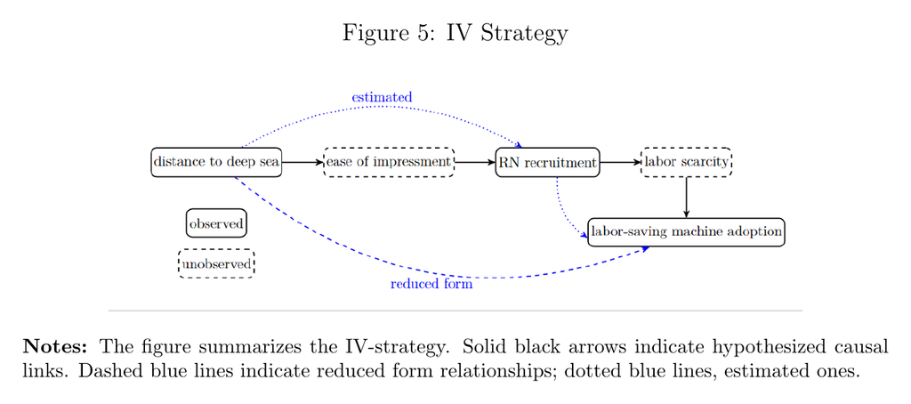

Fig 5: IV design (deep-sea access)

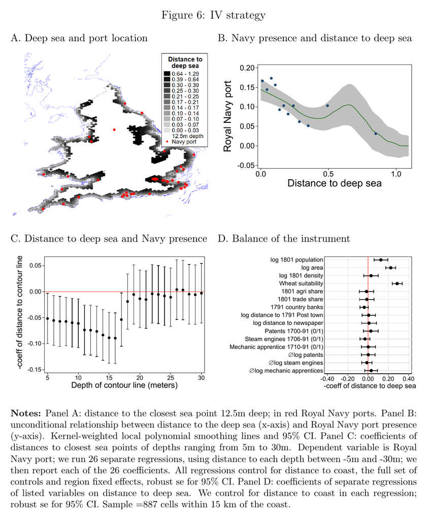

Fig 6: deep-sea distance panels

- $R$ is measured with error and correlated with unobservables ⇒ potential bias
- Focus on **navy** recruitment; instrument = shortest distance to deep, navigable sea
  - Deep-sea line = closest seabed point 12.5 m below the waterline (ships-of-the-line draft ≃7 m; FUD anchoring rule ⇒ 10–15 m)
  - Larger vessels supplied the bulk of naval manpower (Lavery 2020)
- Sample restricted to coastal cells ≤15 km from coast; distance-to-coast controlled directly
  - Isolates *military* labour demand from merchant-marine / trade effects
- Exclusion restriction: within coastal cells and conditional on distance to coast, distance to the 12.5 m line affects adoption only through naval recruitment

Validation

# Results

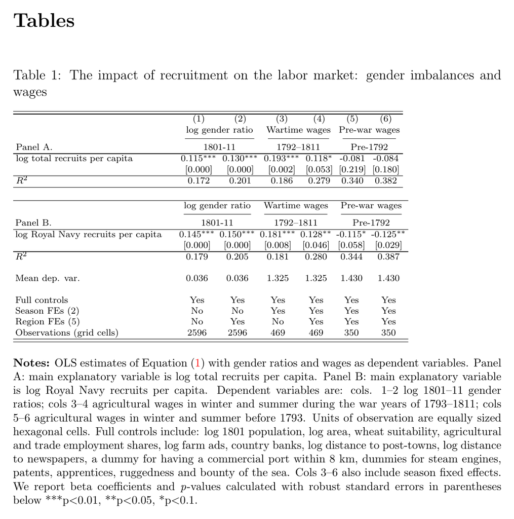

Table 1: recruitment, sex ratios, wages

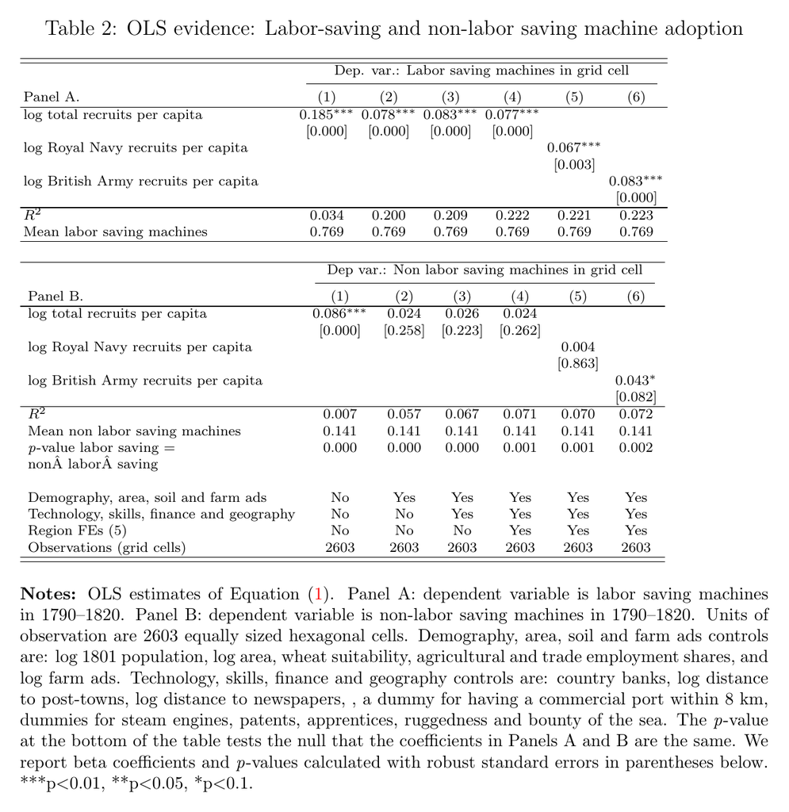

Table 2: OLS adoption

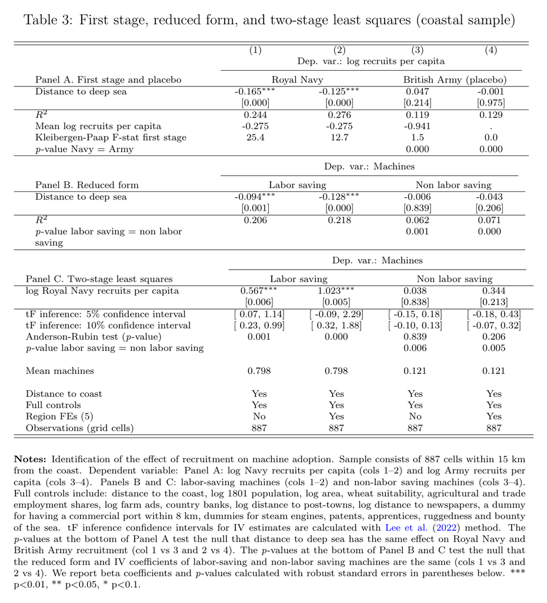

Table 3: IV / 2SLS

**NoteOLS: adoption vs recruitment (Table 2)**

- Labour-saving: 1 s.d. recruitment ⇒ adoption↑ ≃0.2 s.d., large and significant across specifications
- Non-labour-saving: unconditional 0.09 s.d.; falls to ≃0 and insignificant once controls added
- Reject equal coefficients (labour- vs non-labour-saving), $p \leqslant 0.02$
- Only army recruitment shows a (half-sized) effect on non-labour-saving machines

**NoteIV: 2SLS estimates (Table 3)**

- First stage strong ($F \simeq 13$–$25$); reduced form: farther from deep sea ⇒ far fewer labour-saving machines
- **2SLS: 1 s.d. navy recruitment ⇒ 0.6–1.0 s.d. more labour-saving machines**
- Non-labour-saving: null; coefficients significantly different from labour-saving ($p \leqslant 0.01$)
- Anderson–Rubin $p \leqslant 0.002$; Lee et al. (2022) $tF$ 10% CI excludes zero ⇒ weak-instrument concerns dismissed

OLS (≃0.2) → IV (0.6–1.0): the IV coefficient is much larger.[^1]

<sup>1</sup> The authors attribute the gap to (a) severe measurement error — only 1/3 of muster rolls survive, 30% with geographic origin; error-in-variables would explain the whole gap at <30% reliability — and (b) omitted-variable downward bias, since the navy recruited in trading centres with little demand for threshers. Marbach and Hangartner (2020) compliers look like the rest of the sample, so LATE ≃ ATE. Plausible, but a 3–5× jump is a lot to load onto attenuation + OVB alone.

# Synergies

## Labour shortages × mechanical skills

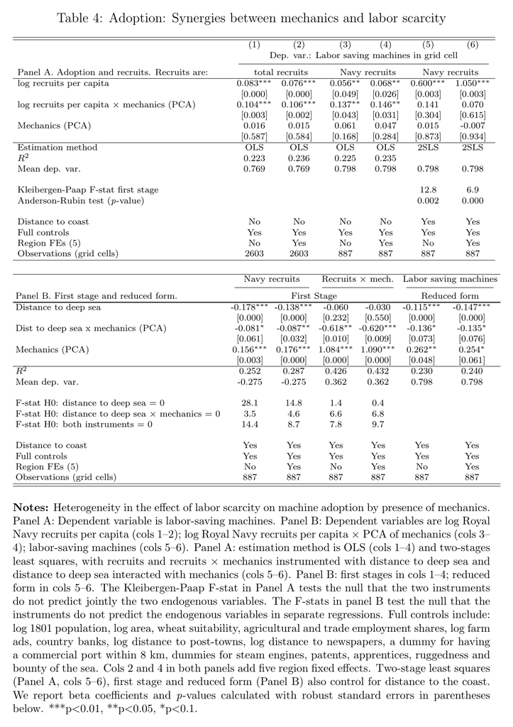

Table 4: synergy (skills × recruitment)

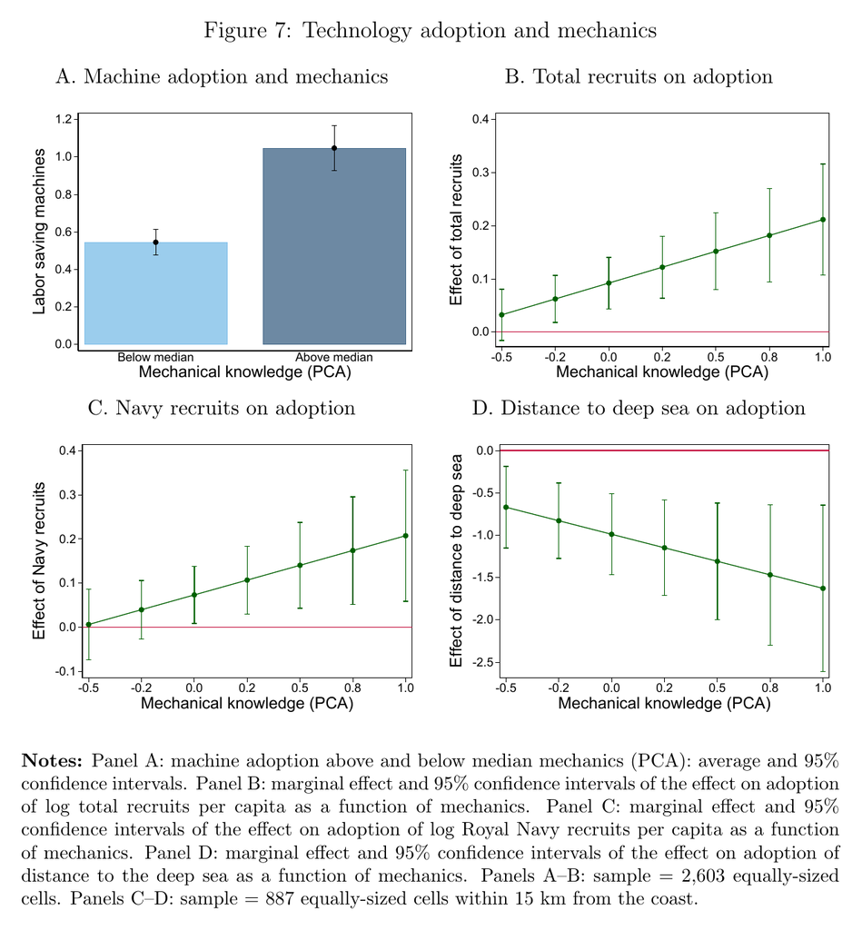

Fig 7: synergy pattern

- Mechanical-knowledge index from apprenticeships (skill supply), machine patents (frontier expertise), and newspaper mentions of machinery
- Higher mechanical skill ⇒ larger effect of recruitment on labour-saving adoption (OLS interaction strong, Table 4-A col 4)
- IV interaction: point estimate close to OLS, but $t$ below conventional significance[^2]
- Reading: Allen (2009) and Mokyr (2009) are **not** mutually exclusive — labour scarcity and human capital reinforced each other

<sup>2</sup> IV with interacted endogenous variables is notoriously under-powered — the two endogenous regressors, the instrument, and the interacted instrument are highly collinear. The “synergy” headline therefore rests on the **reduced form** (interaction $p = 0.08$), not the 2SLS.

## Other drivers of growth

- Finance (Heblich and Trew 2019), coal (Fernihough and O’Rourke 2021), slave wealth (Heblich et al. 2022)
- No significant, systematic interaction with recruitment in reduced form / 2SLS (OLS often wrongly signed)
- Main navy-recruitment effect is stable to including and interacting these factors

# Long-term consequences

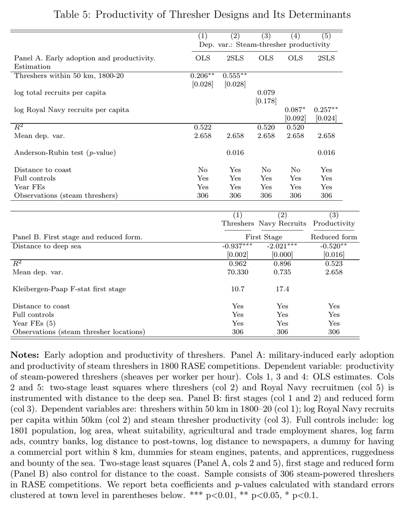

Table 5: RASE thresher productivity

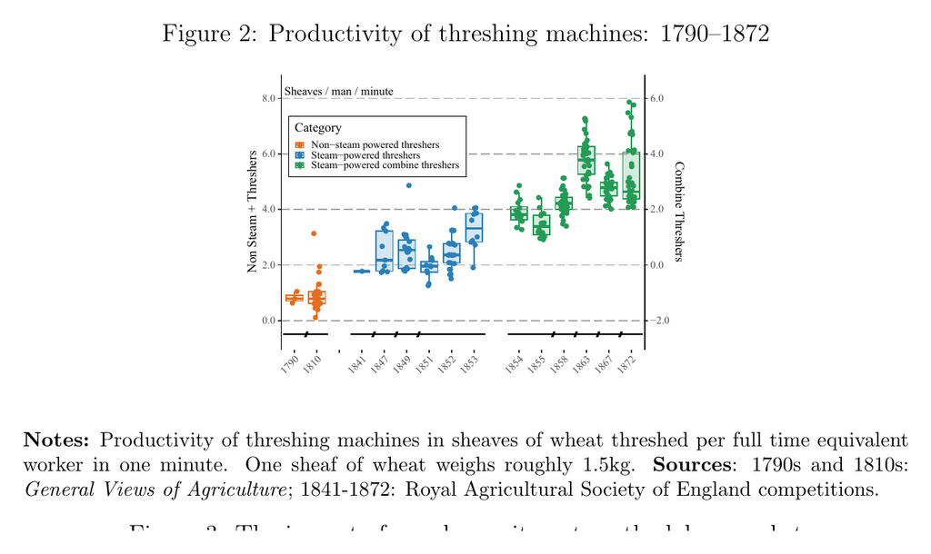

Fig 2: thresher productivity 1790-1872

- Post-1820: machines stayed (2,171 after vs 2,293 before 1820); naval recruitment remains a significant 2SLS predictor of later adoption
- RASE thresher productivity: faster improvement where naval recruitment had promoted early adoption ⇒ consistent with learning-by-doing
- Structural change: movement out of agriculture faster in labour-saving-adoption areas

# Robustness

Reference IV (Table 4, Panel A, cols 5–6): log Navy recruits on labour-saving adoption, **2SLS** = 0.600 / 1.050, p = 0.003; Anderson–Rubin p = 0.002 / 0.000; Kleibergen–Paap F = 12.8 / 6.9. (The alt-explanation appendix tables A.14–A.15 give only qualitative results in the main text; their coefficient tables are in the online appendix, not in these files.)

## Alternative explanations (§4.1, flagged by NBER discussant G. Hanson)

- **Commercial ports / wartime port boom**
  - Worry: all ports siphoned labour during the war, not just naval ones
  - Estimator/test: descriptive Lloyd’s List split, then the main **IV** re-run with commercial-port distance added (Table A.14)
  - Numbers: top-7 naval ports = 95% of RN vessels but 29% of commercial traffic; top-10 commercial ports = 66% of commercial, <4% of Navy; distance-to-12.5m correlates with *military*-port distance, not commercial (Table A.2)
  - Result: first stage, reduced form and IV “stable and significant” adding top-3…15 commercial ports (exact coefficients: online appendix)
  - My concern: still rests on 12.5m uniquely proxying naval access
- **Land market / reverse causality**
  - Worry: recruitment → scarcity → more farm sales → more machines *listed* (adoption is measured from sale ads)
  - Estimator/test: geolocate **>14,500** farm sale/lease ads (1800–20); **placebo** with farm ads as the *dependent* variable, reduced form and IV (Table A.15)
  - Result: RF/IV near-zero, sometimes wrong sign, **never significant** (exact coefficients: online appendix)
  - My concern: shows recruitment doesn’t move the *count* of sales; adoption still coupled to the sales market — a within-sold-farm design would fully separate it

## Robustness checks (§5)

- **Functional form** — DV skew 44.8, 45% zeros
  - Estimator: probit/logit; Poisson + `ivpoisson` control function; zero-inflated Poisson (Tables A.16–A.18)
  - Result: recruitment predicts labour-saving adoption (not non-labour-saving); marginal effects ≈ OLS/LPM
  - Soft spot: reduced-form probit only p = 0.1
- **Matching** — balance on observables
  - **CEM** = Coarsened Exact Matching (Iacus, King & Porro 2012): coarsen each covariate into bins, **exact-match** treated vs control within the same bin, drop unmatched strata, weight the rest — nonparametric balance with no functional-form assumption
  - also entropy balancing (Hainmueller 2012) and nearest-neighbour (Table A.19); treated = recruitment above median
  - Result: **OLS** on matched/re-weighted data ⇒ effects near baseline (entropy balancing larger); R² 3–4× higher
  - Limit: observables only — the unobservables are the IV’s job
- **Spatial inference** — spatial correlation understates SEs
  - No spatial unit root: Müller–Watson (2024), I(0) not rejected (p ≈ 0.35), I(1) rejected
  - Four fixes: Conley (1999) SEs at 50–1000 km + county clustering (A.21); Ibragimov–Müller (2010) 4-region exact-t — **RF/IV p = 0.009 / 0.024**, OLS 0.066–0.073, first stage 0.090 (A.22); linear coordinate controls (A.23); Conley–Kelly (2025) lat/long B-spline (A.24–A.25)
  - Result: survives all; assuming longer decay ⇒ *more* significant
- **Exclusion restriction** — the crux
  - Support: distance-to-deep-sea uncorrelated with pre-war traits; doesn’t predict maritime trade, army recruitment, or farm ads
  - **Conley et al. (2012) “plausibly exogenous”**: relaxes the strict exclusion (instrument’s *direct* effect γ on the outcome = 0); instead assume γ lies in a range and trace how the IV confidence interval widens (union-of-CI and local-to-zero methods)
  - **Fig A.14** (image not embedded — online appendix): y-axis = IV coefficient bound; x-axis = assumed direct effect γ of deep-sea on adoption; vertical line = reduced-form coefficient. Reading: the IV stays significant unless γ exceeds about **half** the reduced form
  - My concern: “> half the RF” is a judgement call — a direct coastal-culture channel (Mokyr) interacting with mechanics could be that large

## Alternative samples, controls, definitions (§5.5) — why each

- **Urban cells** (A.26): farm implements unlikely to be used in towns ⇒ excluded to focus on agriculture; including them doesn’t change results
- **Cells never in farm ads** (A.27): adoption is measured from ads ⇒ excluding never-advertised cells tests ad-coverage selection; results hold
- **Cells >50 km from a newspaper** (A.28): newspaper coverage may select cells ⇒ including far cells tests coverage bias
- **Port / victualling / Wales exclusions** (A.29–A.33): several direct confounds
  - naval-port cells: wartime naval activity may hit local labour markets directly
  - 19 victualling yards: concentrated food demand may itself spur technology
  - commercial ports: expand in war ⇒ tighter labour markets
  - Wales: sparse, land unsuitable for cereals ⇒ little thresher incentive; including biases in the paper’s favour
  - Result: drop cells within 8 km of ports/victualling (even both, **halving** the sample) ⇒ OLS/RF robust; **2SLS** point larger than baseline but imprecise (p = 0.2)
- **Coastal cutoff 15 km** = half a day’s walk (Fig A.15): IV and RF stable across cut-offs
- **Enclosures** (A.34): Parliamentary enclosure could drive adoption ⇒ control pre-war (1792) and wartime (1793–1815) enclosure shares; wartime enclosure promotes adoption, pre-war zero/negative; recruitment effect unaffected
- **Wheat prices** (A.35): food inflation could affect adoption ⇒ high inflation slows adoption but leaves the factor-bias effect unchanged
- **Offshore centroid** (A.36): distance-to-sea is truncated at 0 for cells whose centroid is at sea ⇒ add an indicator; robust
- **Thresher-only** (A.37): “labour-saving” classification may err ⇒ re-estimate with threshers only (unambiguous, expensive, likely listed); near-identical
- **Recruitment measure** (A.38): re-scale by 1801 male population; log with an explicit extensive margin (−2 for zero cells, Chen–Roth 2023); robust in OLS & IV

## Further tests I would want

- **Instrument depth**: report Panel C’s deep-tail explicitly and reconcile with the “depth lines highly correlated” claim; show first-stage F by contour
- **Culture confound**: proxy Mokyr-culture directly (dissenting academies, subscription libraries, Lunar-Society networks) and test whether the synergy survives conditioning on it *and* its interaction with the instrument
- **Adoption measure**: validate against 1830s machinery-census levels; within-sold-farm adoption model
- **Synergy identification**: `distance &times; mechanics` is weak (Panel B F 3.5–6.8) ⇒ LIML/CLR or over-ID check on the interaction, not bare 2SLS

# Revisions: March 6 → June 5, 2026

Revisions: Voth, Caprettini & Trew, “Fighting for Growth” — March 6 (old) vs June 5 (new), 2026

| Page (old) | Points | Old | New |
| --- | --- | --- | --- |
| 1 | Draft date | March 6, 2026 | June 5, 2026 |
| 7 | Agricultural shares wording | “these shares were equal at 31%” | “output and employment shares in agriculture were both equal to 31%” |
| 11 | Hot-press sample window | newspapers “published in 1785–1820” | newspapers “published in 1790–1820” |
| 12 | Recruits wording | “origins of these over 45,000 recruits” | “origins of over 45,000 of these recruits” |
| 14 | Pre-war wage interpretation (major) | “it is not visible prior to the outbreak of war with France (col. 5 and 6).” | “high recruitment areas had prior of the war lower wages (col. 5 and 6), suggesting that wartime recruitment significantly reshaped labor markets.” |
| 14 | OLS equation notation | Mᵢ = αᵣ + βRᵢ + γXᵢ′ + uᵢ | Mᵢ = αᵣ + βRᵢ + Xᵢ′γ + uᵢ |
| 27 | Reverse-causation placebo (Lloyd's List) | “have the wrong sign, are close to zero and not significant” | “have sometimes the wrong sign, are close to zero and never significant” |
| 28 | Spatial-robustness p-values (App. Table A.22) | RF/IV p = 0.007 and 0.023; first stage 0.086 | RF/IV p = 0.009 and 0.024; first stage 0.090 |
| 28 | New robustness check added | (absent) | “Fourth, we follow Conley and Kelly (2025) and include in all regressions a B-spline [in coordinates]” |
| 37 | RASE productivity table — added control | “Season FEs” | “Wheat price & season FEs” |
| 37 | RASE productivity table — re-estimated | e.g. 0.118* (F = 1.325 / 1.430) | e.g. 0.147** (F = 1.787 / 1.358) |
| 41 | RASE productivity units (table note) | “sheaves per worker per hour” | “sheaves per worker per minute” |
| 39, 43 | Appendix table values updated | e.g. p39 blank cell “.”; p43 “1.4 1.6 …” | e.g. p39 “-0.941”; p43 “1.9 2.1 …” |

# Appendix map (one-liners)

Source: working-paper version, CEPR DP 17881 (stored in `paper_digest.sqlite`, `doc = 'DP17881'`).

**Appendix figures**

- Figure A.1 — British men employed at sea 1790–1815: scale of naval manpower withdrawal over the war.
- Figure A.2 — sex ratios vs recruitment: recruitment skewed local sex ratios, evidencing male labour withdrawal.
- Figure A.3 — bicolor map of machine adoption × military recruitment: geographic co-movement of the two key variables.
- Figure A.4 — depth requirement for safe anchorage: physical basis for the 12.5 m deep-sea-distance instrument.
- Figure A.5 — tides in Portsmouth and Liverpool: tidal range is small vs ship draft, justifying a fixed depth cutoff.
- Figure A.6 — IV strategy validation: deep-sea distance predicts naval recruitment (first-stage credibility).
- Figure A.7 — error-in-variables estimates: measurement-error-corrected OLS; reliability <30% closes the OLS–IV gap.
- Figure A.8 — matching exercises: the adoption effect survives covariate matching.
- Figure A.9 — alternative coastal-sample definitions: effect stable across coastal-cutoff choices.

**Appendix tables**

- Table A.1 — gender imbalances and recruitment: recruitment raised local male scarcity.
- Table A.2 — validation: recruitment measure cross-checked against an external source.
- Table A.3 — validation: second cross-check of the recruitment/instrument data.
- Table A.4 — analysis of compliers: IV compliers resemble the full sample, so LATE ≈ ATE.
- Table A.5 — OLS–IV weights decomposition: unpacks why IV exceeds OLS.
- Table A.6 — extensive margin (LPM, probit, logit): adoption result holds on the 0/1 margin.
- Table A.7 — discrete-choice count models (Poisson, negative binomial): robust to count-data models.
- Table A.8 — spatial standard errors: inference robust to spatial correlation.
- Table A.9 — including urban areas: robust to adding towns.
- Table A.10 — including areas far from a newspaper: robust to newspaper-coverage selection.
- Table A.11 — excluding areas near victualling centres: robust to dropping Navy-provisioning towns.
- Table A.12 — excluding Wales: robust to an England-only sample.
- Table A.13 — recruits per men: robust to an alternative recruitment normalisation.
- Table A.14 — threshing machines: robust to an alternative adoption measure.

# 感想

<sup>3</sup> 交差項付き IV は第一段階の検出力不足で有名なので、著者の弁明は妥当。しかし「両説は補完的」という主論の実証的支柱がこの一点に集中しているのは弱い。

<sup>4</sup> 測定誤差(muster roll の 1/3 のみ現存、地理情報 30%)と下方バイアスで説明。error-in-variables なら信頼性30%未満で全乖離を説明できる、という補遺の図は誠実。それでも、これだけの乖離を減衰バイアス+OVB だけに負わせるのは大きい。compliers が標本と似る(Marbach–Hangartner)ので LATE≈ATE という主張も、乖離の大きさを完全には消さない。

<sup>5</sup> 漁民は農業労働者と別集計で、多くが海軍から免除(Dancy 2018)という反論はある。ただし「maritime district = 海軍需要のみ」を完全には保証しない。